# Analysis of the Activity Monitoring Data

Vasilena Taralova

February 8, 2017

# 1 Introduction

It is now possible to collect a large amount of data about personal movement using activity monitoring devices such as a [Fitbit](http://www.fitbit.com/eu), [Nike Fuelband](http://www.nike.com/us/en_us/c/nikeplus-fuelband), or [Jawbone Up](https://jawbone.com/up). These type of devices are part of the “quantified self” movement – a group of enthusiasts who take measurements about themselves regularly to improve their health, to find patterns in their behavior, or because they are tech geeks. But these data remain under-utilized both because the raw data are hard to obtain and there is a lack of statistical methods and software for processing and interpreting the data.

In this project we analyze the data from a personal activity monitoring device. This device collects data at 5-minute intervals throughout the day. The data consists of two months of data from an anonymous individual collected during the months of October and November 2012 and includes the number of steps taken in 5-minute time intervals each day.

# 2 Overview of the dataset

The data for this project can be downloaded from:

- **Dataset**: [Activity monitoring data](https://d396qusza40orc.cloudfront.net/repdata%2Fdata%2Factivity.zip)

The variables included in this dataset are:

- **steps**: Number of steps taken in a 5-minute interval (missing values are coded as NA)
- **date**: The date on which the measurement was taken in YYYY-MM-DD format
- **interval**: Identifier for the 5-minute interval in which measurement was taken

The dataset is stored in a comma-separated-value (CSV) file and there are a total of 17568 observations.

# 3 Loading the data

First we load the packages that we will use:

```r
library(ggplot2)
library(plyr)
library(knitr)
library(gridExtra)
```

Our next step is to set the working directory:

```r
setwd("D:/Coursera_Reproducible_Research/Project_Assignment_1")
```

Then we download the archive and we unzip it:

```r
if(!file.exists("./Activity_Data.zip")){

    fileUrl <- "https://d396qusza40orc.cloudfront.net/repdata%2Fdata%2Factivity.zip"

    download.file(fileUrl, destfile = "./Activity_Data.zip")

}

unzip(zipfile = "./Activity_Data.zip", exdir = ".")
```

Finally we read the data into the “activity” data frame:

```r
activity <- read.csv(file = "./activity.csv",
                     header = TRUE,
                     stringsAsFactors = FALSE)
```

# 4 Structure of the dataset

For this part of the project we ignore the missing values in the dataset.

We start with taking a look at the structure of the “activity” data frame:

```r
head(activity, 20)
```

```
   steps       date interval
1     NA 2012-10-01        0
2     NA 2012-10-01        5
3     NA 2012-10-01       10
4     NA 2012-10-01       15
5     NA 2012-10-01       20
6     NA 2012-10-01       25
7     NA 2012-10-01       30
8     NA 2012-10-01       35
9     NA 2012-10-01       40
10    NA 2012-10-01       45
11    NA 2012-10-01       50
12    NA 2012-10-01       55
13    NA 2012-10-01      100
14    NA 2012-10-01      105
15    NA 2012-10-01      110
16    NA 2012-10-01      115
17    NA 2012-10-01      120
18    NA 2012-10-01      125
19    NA 2012-10-01      130
20    NA 2012-10-01      135
```

```r
str(activity)
```

```
'data.frame':   17568 obs. of  3 variables:
 $ steps   : int  NA NA NA NA NA NA NA NA NA NA ...
 $ date    : chr  "2012-10-01" "2012-10-01" "2012-10-01" "2012-10-01" ...
 $ interval: int  0 5 10 15 20 25 30 35 40 45 ...
```

We see that the variables “steps” and “interval” are of type integer and “date” is of type character. Finally, we provide a summary statistic of the data:

```r
summary(activity)
```

```
     steps            date              interval
 Min.   :  0.00   Length:17568       Min.   :   0.0
 1st Qu.:  0.00   Class :character   1st Qu.: 588.8
 Median :  0.00   Mode  :character   Median :1177.5
 Mean   : 37.38                      Mean   :1177.5
 3rd Qu.: 12.00                      3rd Qu.:1766.2
 Max.   :806.00                      Max.   :2355.0
 NA's   :2304
```

From the summary of the data we see that the mean number of steps for all days and all time intervals is 37. Since each day is divided into 5-minute time intervals, and a day has $24\times 60 = 1440$ minutes, this means that there are $1440/5=288$ time intervals per day. As we can see from the overview of the data frame above, the 5-minute time intervals are written as hours and minutes concatenated together (e.g. 115 is 1:15 am).

# 5 Mean total number of steps taken per day

Next, we calculate the total number of steps taken per day. In the character vector “unique.dates” we store the the dates on which the measurements were taken.

```r
unique.dates <- unique(activity$date)

length(unique.dates)
```

```
[1] 61
```

We see that there are 61 days of measurements.

With the help of the R function “sapplly()” we create the integer vector “total.steps” which contains the total number of steps taken each day:

```r
total.steps <- sapply(unique.dates, function(day){

    sum(subset(activity, date == day)$steps, na.rm = TRUE)
})
```

R treats missing values (for number of steps) as 0 when calculating the total sum of steps, i.e., the sum of steps becomes 0 if all of the “steps” values are NA for a given date.  
Below we check if we correctly computed the vector “total.steps”, i.e., we compare the sum of the elements of the vector “total.steps” to the sum of all steps in the “activity” data frame:

```r
sum(total.steps) == sum(activity$steps, na.rm = TRUE)
```

```
[1] TRUE
```

It turns out that, indeed, our calculations are correct.

## 5.1 Histogram of the total number of steps taken each day

Next we make a histogram of the total number of steps taken each day. We use the “ggplot2” plotting system:

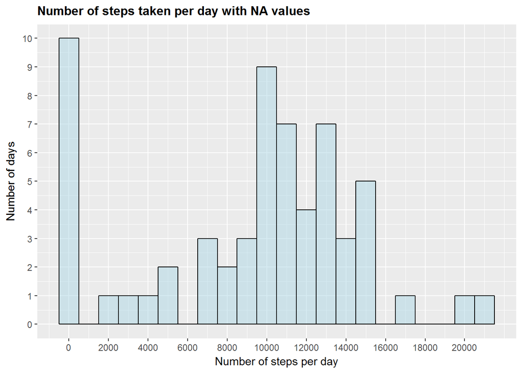

```r
h1 <- ggplot(data = data.frame(steps = total.steps), aes(x = steps)) +
         geom_histogram(binwidth = 1000,
                        colour = "black",
                        fill = "lightblue",
                        alpha = 0.5) +
         scale_x_continuous(breaks = seq(0, 20000, 2000)) +
         scale_y_continuous(breaks = seq(0, 10, 1)) +
         labs(x = "Number of steps per day",
              y = "Number of days") +
         ggtitle("Number of steps taken per day with NA values") +
         theme(plot.title = element_text(size = 12, face = "bold"))

h1
```

We see from the histogram above that the biggest part of the measurement days (which are 61 in total) are with zero number of days. As we will see later, this is due to the fact that there are 8 days with no data on the number of steps. In turn, this results in the total sums of steps for these days to be equal to 0 (because when computing sums R treats NA values as 0). From the histogram we also see that for most days the number of steps is between 10000 and 15000.

## 5.2 Mean and median of the total number of steps taken per day

The mean and median total number of steps taken per day are given below:

```r
mean(total.steps)
```

```
[1] 9354.23
```

```r
median(total.steps)
```

```
[1] 10395
```

# 6 Average daily activity pattern

Next we make a time series plot of the 5-minute intervals (x-axis) and the mean number of steps taken in this interval, averaged across all days (y-axis). We use the “aggregate()” function (from the R “stats” package) to generate a data frame called “avg.steps” which contains all 288 5-minute time intervals and the corresponding mean number of steps taken, averaged across all days.

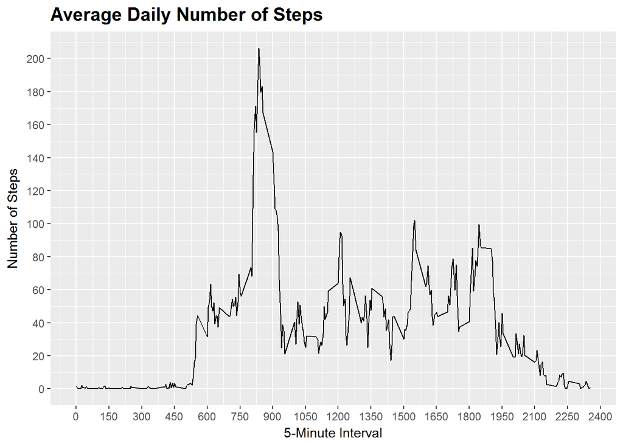

```r
avg.steps <- aggregate(steps ~ interval,
                       data = activity,
                       FUN = "mean",
                       na.action = na.omit)


ggplot(data = avg.steps, aes(x = interval, y = steps)) +
         geom_line() +
         scale_x_continuous(breaks = seq(0, 2500, 150)) +
         scale_y_continuous(breaks = seq(0, 200, 20)) +
         labs(x = "5-Minute Interval",
              y = "Number of Steps") +
         ggtitle("Average Daily Number of Steps") +
         theme(plot.title = element_text(size = 15, face = "bold"))
```

From the plot above we see that the largest mean number of steps are taken in the hours between 7:50 am and 9:00 am. The next question we are going to answer is “Which 5-minute interval, on average across all the days in the dataset, contains the maximum number of steps?”. As we see from the code below, the 5-minute interval, which contains the maximum number of steps is the 835-th interval (or 8:35 am).

```r
avg.steps$interval[which(avg.steps$steps == max(avg.steps$steps))]
```

```
[1] 835
```

# 7 Imputing missing values

We notice that there are a lot of observations with missing number of steps (coded as NA). Below we calculate the number and perecentage of these missing values:

```r
missing.values <- is.na(activity$steps)

sum(missing.values)
```

```
[1] 2304
```

```r
(sum(missing.values)/dim(activity)[1])*100
```

```
[1] 13.11475
```

There are 2304 missing values for the number of steps, which account for 13.1% of all observations in the “activity” data frame. The presence of missing data may lead to bias in some calculations or summaries of the data. Therefore we are going to fill in all of the missing values in the dataset with suitable data. First we write the function “detect_NA_days()” which extracts the indices of the days (we have 61 unique days of measurements) with no available data on the number of steps, as well as the indices of the days with partially missing data on the number of steps. The function returns a list of two integer vectors:

```r
detect_NA_days <- function(mydata){

    days.na = vector(mode = "integer")

    na.partial.days = vector(mode = "integer")

    unique.dates <- unique(mydata$date)

    for(i in 1:length(unique.dates)){

        single.day <- subset(mydata, date == unique.dates[i])$steps

        nobs <- length(single.day)

        missing.values <- is.na(single.day)

        if(sum(missing.values) == nobs){

            days.na <- c(days.na, i)

        }else if(sum(missing.values) > 0) {

            na.partial.days <- c(na.partial.days, i)
        }
    }

    return(list(days.na, na.partial.days))
}
```

Next, we apply the function to the “activity” data frame and we see that there are 8 days with entirely missing measurements of the number of steps and there are no days with partially missing data:

```r
l <- detect_NA_days(activity)

na.days <- l[[1]]
partial.na.days <- l[[2]]

na.days
```

```
[1]  1  8 32 35 40 41 45 61
```

```r
partial.na.days
```

```
integer(0)
```

We also list the days with missing values:

```r
unique.dates[na.days]
```

```
[1] "2012-10-01" "2012-10-08" "2012-11-01" "2012-11-04" "2012-11-09"
[6] "2012-11-10" "2012-11-14" "2012-11-30"
```

Our strategy for imputing the missing numbers of steps is the following. If the day of the week is a working day (Monday to Friday) we take the average number of steps for each 5-minute time interval across all working days. If, on the other hand, the day of the week is a weekend day (Saturday or Sunday) we take the average number of steps for each 5-minute time interval across all weekend days. In order to determine what day of the week each date is, we first transform the “date” variable into the date format “POSIXlt”:

```r
activity$date <- as.POSIXlt(activity$date)
```

Then we add a new variable, called “day”, to the “activity” data frame. The “day” variable is of type character and is equal to “weekend” if the date corresponds to a weekend day (Saturday or Sunday), and is equal to “weekday” if the date is a working day (Monday to Friday). In order to do this we make use of the R function “weekdays()” from the “base” package. This function works with objects of type “POSIXt” or “Date”. Therefore, we first transformed the character variable “date” into a “POSIXlt” object. We also use the “mutate()” function from the “plyr” package. We need this function to simultaneously create the new character variable – “day”, and to add it to the “activity” data frame:

```r
weekend.days <- c("Saturday", "Sunday")

activity <- mutate(activity,
                   day = ifelse(weekdays(date) %in% weekend.days,
                                "weekend", "weekday"))
```

Next, with the “aggregate()” function form the “stats” package we generate the “avg.steps.weekday” data frame which contains the average number of steps taken for each 5-minute time interval, grouped by the “day” variable (i.e. averaged across all working or weekend days):

```r
avg.steps.weekday <- aggregate(steps ~ interval + day,
                               data = activity,
                               FUN = "mean",
                               na.action = na.omit)
```

Below we create a new data frame, called “activity.impute”, which is equal to the original dataset but with the missing data filled in:

```r
activity.impute <- activity

activity.impute[activity.impute$date %in% unique.dates[na.days] &
                activity.impute$day == "weekday", "steps"] <- avg.steps.weekday[avg.steps.weekday$day == "weekday" ,"steps"]

activity.impute[activity.impute$date %in% unique.dates[na.days] &
                activity.impute$day == "weekend", "steps"] <- avg.steps.weekday[avg.steps.weekday$day == "weekend" ,"steps"]
```

Next, for the new dataset we compute the total number of steps taken per day as well as its mean and median:

```r
total.steps.imp <- aggregate(steps ~ as.character(date),
                             data = activity.impute,
                             FUN = "sum")

mean(total.steps.imp$steps)
```

```
[1] 10762.05
```

```r
median(total.steps.imp$steps)
```

```
[1] 10571
```

and we compare them to the respective mean and median for the original “activity” data frame:

```r
mean(total.steps)
```

```
[1] 9354.23
```

```r
median(total.steps)
```

```
[1] 10395
```

As we can see, the two means and medians differ but they are very close numbers. Both the mean and the median of the imputed dataset are bigger than these of the original dataset, which is expected because in the original “activity” dataset there are a lot of missing values which are filled in in the “activity.impute” dataset. What happens is that the NA values in the “activity” data frame are taken as zeros when computing the total number of steps per day and these zeros do not contribute to the value of the mean. On the other hand, in the “activity.impute” data frame the missing data is filled in, and hence, not all of the imputed values for the number of steps are zeros. Thus the nonzero imputed data (which was previously counted as zeros) now contributes to the mean and the mean becomes bigger. We show a histogram of the total number of steps taken each day for the “activity.impute” dataset:

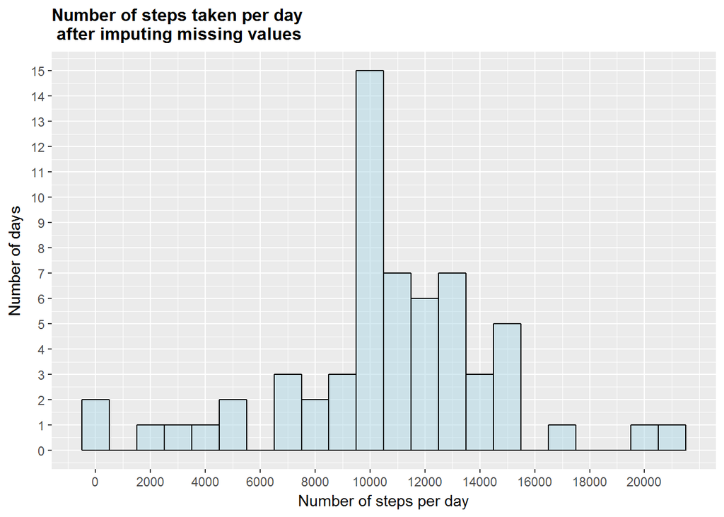

```r
h2 <- ggplot(data = data.frame(steps = total.steps.imp$steps), aes(x = steps)) +
         geom_histogram(binwidth = 1000,
                        colour = "black",
                        fill = "lightblue",
                        alpha = 0.5) +
         scale_x_continuous(breaks = seq(0, 20000, 2000)) +
         scale_y_continuous(breaks = seq(0, 20, 1)) +
         labs(x = "Number of steps per day",
              y = "Number of days") +
         ggtitle("Number of steps taken per day \n after imputing missing values") +
         theme(plot.title = element_text(size = 12, face = "bold"))

h2
```

Below we show side by side the histograms of the total number of steps taken per day in the case of missing values and in the case of imputed values:

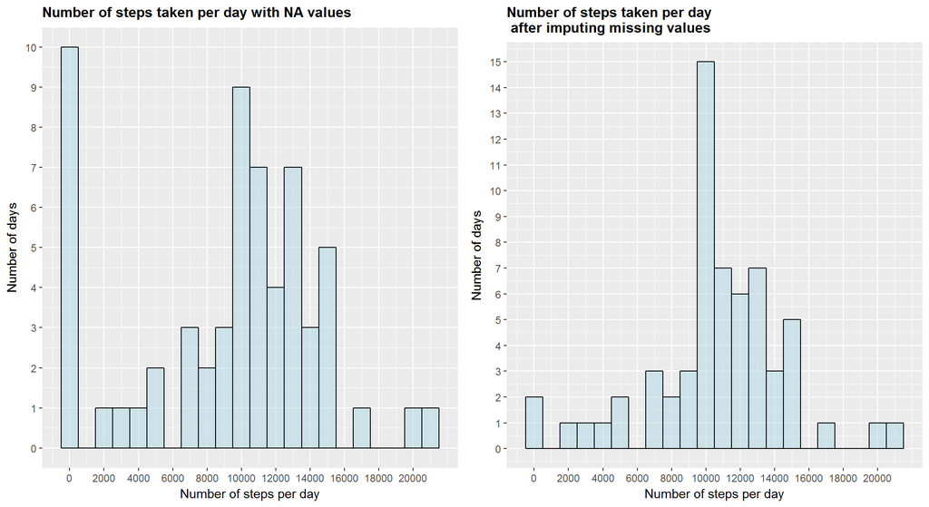

```r
grid.arrange(grobs = list(h1,h2), ncol = 2)
```

As we can see from the plot, the number of days with 0 number of steps is 10 when the missing values are not filled in, and then, when we impute them, the number of days with 0 steps is reduced by 8 and becomes equal to 2. Note that 8 is exactly the number of days we identified to contain NA number of steps for all of their 5-minute time intervals. Thus, when we impute the missing number of steps for these 8 days, their total number of steps is no longer equal to 0.

# 8 Activity patterns during weekdays and weekends

Finally, we compare the activity patterns during working days and weekends. With the help of the “avg.steps.weekday” data frame we make a panel plot containing a time series plot of the 5-minute intervals (x-axis) and the average number of steps taken, averaged across all working or weekend days (y-axis):

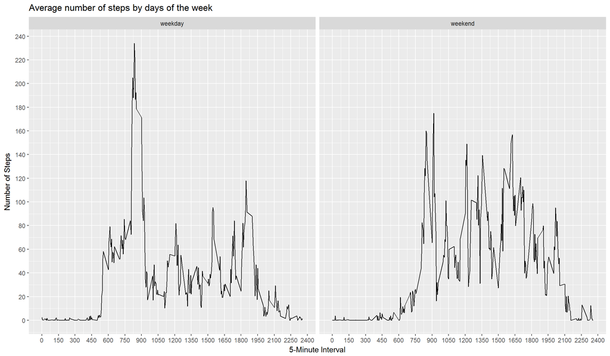

```r
ggplot(data = avg.steps.weekday, aes(x = interval, y = steps)) +
    geom_line() +
    labs(x = "5-Minute Interval",
         y = "Number of Steps") +
    scale_x_continuous(breaks = seq(0, 2500, 150)) +
    scale_y_continuous(breaks = seq(0, 300, 20)) +
    ggtitle("Average number of steps by days of the week") +
    facet_wrap(~day)
```

# 9 Generating an “md” file

We produce an “md” file together with a folder named “figures” in the working directory. The folder “figures” contains all figures from the report. The corresponding command is given below:

```r
knit(input = "D:/Coursera_Reproducible_Research/Project_Assignment_1/PA1_template.Rmd",
     output = "D:/Coursera_Reproducible_Research/Project_Assignment_1/PA1_template.md")
```